# Project: Investigate a Dataset - The TMDb Movie Dataset

- Introduction
- Data Wrangling
- Exploratory Data Analysis
- Conclusions

## Introduction

> The Movie Database provides data about 10000 movies along with their genres, popularity, budgets, revenues and more.  
> I plan to explore the
> - Average duration of movies by year
> - Popular genres from year to year
> - Popular production companies over the years
> - Factors that possibly influence movies with high revenues

## Data Wrangling

### General Properties

```python
# importing necessary libraries and loading the dataset
import pandas as pd
import numpy as np
import matplotlib.pyplot as plt
%matplotlib inline

movie_df = pd.read_csv('/content/tmdb-movies.csv')
```

```python
#inspecting the first 3 rows of the dataframe
movie_df.head(3)
```

|  | id | imdb_id | popularity | budget | revenue | original_title | cast | homepage | director | tagline | ... | overview | runtime | genres | production_companies | release_date | vote_count | vote_average | release_year | budget_adj | revenue_adj |
| --- | --- | --- | --- | --- | --- | --- | --- | --- | --- | --- | --- | --- | --- | --- | --- | --- | --- | --- | --- | --- | --- |
| 0 | 135397 | tt0369610 | 32.985763 | 150000000 | 1513528810 | Jurassic World | Chris Pratt\|Bryce Dallas Howard\|Irrfan Khan\|Vi... | http://www.jurassicworld.com/ | Colin Trevorrow | The park is open. | ... | Twenty-two years after the events of Jurassic ... | 124 | Action\|Adventure\|Science Fiction\|Thriller | Universal Studios\|Amblin Entertainment\|Legenda... | 6/9/15 | 5562 | 6.5 | 2015 | 1.379999e+08 | 1.392446e+09 |
| 1 | 76341 | tt1392190 | 28.419936 | 150000000 | 378436354 | Mad Max: Fury Road | Tom Hardy\|Charlize Theron\|Hugh Keays-Byrne\|Nic... | http://www.madmaxmovie.com/ | George Miller | What a Lovely Day. | ... | An apocalyptic story set in the furthest reach... | 120 | Action\|Adventure\|Science Fiction\|Thriller | Village Roadshow Pictures\|Kennedy Miller Produ... | 5/13/15 | 6185 | 7.1 | 2015 | 1.379999e+08 | 3.481613e+08 |
| 2 | 262500 | tt2908446 | 13.112507 | 110000000 | 295238201 | Insurgent | Shailene Woodley\|Theo James\|Kate Winslet\|Ansel... | http://www.thedivergentseries.movie/#insurgent | Robert Schwentke | One Choice Can Destroy You | ... | Beatrice Prior must confront her inner demons ... | 119 | Adventure\|Science Fiction\|Thriller | Summit Entertainment\|Mandeville Films\|Red Wago... | 3/18/15 | 2480 | 6.3 | 2015 | 1.012000e+08 | 2.716190e+08 |

3 rows × 21 columns

```python
# checking the total number of rows and columns
movie_df.shape
```

```
(10866, 21)
```

```python
# checking for datatypes and missing data
movie_df.info()
```

```
<class 'pandas.core.frame.DataFrame'>
RangeIndex: 10866 entries, 0 to 10865
Data columns (total 21 columns):
 #   Column                Non-Null Count  Dtype
---  ------                --------------  -----
 0   id                    10866 non-null  int64
 1   imdb_id               10856 non-null  object
 2   popularity            10866 non-null  float64
 3   budget                10866 non-null  int64
 4   revenue               10866 non-null  int64
 5   original_title        10866 non-null  object
 6   cast                  10790 non-null  object
 7   homepage              2936 non-null   object
 8   director              10822 non-null  object
 9   tagline               8042 non-null   object
 10  keywords              9373 non-null   object
 11  overview              10862 non-null  object
 12  runtime               10866 non-null  int64
 13  genres                10843 non-null  object
 14  production_companies  9836 non-null   object
 15  release_date          10866 non-null  object
 16  vote_count            10866 non-null  int64
 17  vote_average          10866 non-null  float64
 18  release_year          10866 non-null  int64
 19  budget_adj            10866 non-null  float64
 20  revenue_adj           10866 non-null  float64
dtypes: float64(4), int64(6), object(11)
memory usage: 1.7+ MB
```

### Data Cleaning

```python
# checking for duplicates
movie_df.duplicated().sum()
```

```
1
```

```python
# dropping duplicates
movie_df.drop_duplicates(inplace=True)
```

```python
# checking for duplicates again
movie_df.duplicated().sum()
```

```
0
```

```python
# removing columns
removed_columns = ['imdb_id', 'tagline', 'keywords', 'overview', 'homepage', 'vote_count', 'release_date', 'budget', 'revenue']

movie_df.drop(removed_columns, axis=1, inplace=True)
```

```python
# confirming the columns have been removed
movie_df.head(3)
```

|  | id | popularity | original_title | cast | director | runtime | genres | production_companies | vote_average | release_year | budget_adj | revenue_adj |
| --- | --- | --- | --- | --- | --- | --- | --- | --- | --- | --- | --- | --- |
| 0 | 135397 | 32.985763 | Jurassic World | Chris Pratt\|Bryce Dallas Howard\|Irrfan Khan\|Vi... | Colin Trevorrow | 124 | Action\|Adventure\|Science Fiction\|Thriller | Universal Studios\|Amblin Entertainment\|Legenda... | 6.5 | 2015 | 1.379999e+08 | 1.392446e+09 |
| 1 | 76341 | 28.419936 | Mad Max: Fury Road | Tom Hardy\|Charlize Theron\|Hugh Keays-Byrne\|Nic... | George Miller | 120 | Action\|Adventure\|Science Fiction\|Thriller | Village Roadshow Pictures\|Kennedy Miller Produ... | 7.1 | 2015 | 1.379999e+08 | 3.481613e+08 |
| 2 | 262500 | 13.112507 | Insurgent | Shailene Woodley\|Theo James\|Kate Winslet\|Ansel... | Robert Schwentke | 119 | Adventure\|Science Fiction\|Thriller | Summit Entertainment\|Mandeville Films\|Red Wago... | 6.3 | 2015 | 1.012000e+08 | 2.716190e+08 |

```python
# checking for null values
movie_df.isnull().sum()
```

```
id                         0
popularity                 0
original_title             0
cast                      76
director                  44
runtime                    0
genres                    23
production_companies    1030
vote_average               0
release_year               0
budget_adj                 0
revenue_adj                0
dtype: int64
```

```python
# dropping null values
movie_df.dropna(inplace=True)
```

```python
# confirming that there are no null values
movie_df.isnull().sum()
```

```
id                      0
popularity              0
original_title          0
cast                    0
director                0
runtime                 0
genres                  0
production_companies    0
vote_average            0
release_year            0
budget_adj              0
revenue_adj             0
dtype: int64
```

## Exploratory Data Analysis

```python
# computing the summary statistics for the numerical variables
movie_df[['popularity', 'runtime', 'vote_average', 'budget_adj', 'revenue_adj']].describe()
```

|  | popularity | runtime | vote_average | budget_adj | revenue_adj |
| --- | --- | --- | --- | --- | --- |
| count | 9772.000000 | 9772.000000 | 9772.000000 | 9.772000e+03 | 9.772000e+03 |
| mean | 0.694721 | 102.926627 | 5.963528 | 1.941599e+07 | 5.705309e+07 |
| std | 1.036931 | 27.877432 | 0.913174 | 3.566634e+07 | 1.514499e+08 |
| min | 0.000188 | 0.000000 | 1.500000 | 0.000000e+00 | 0.000000e+00 |
| 25% | 0.232710 | 90.000000 | 5.400000 | 0.000000e+00 | 0.000000e+00 |
| 50% | 0.419762 | 100.000000 | 6.000000 | 3.061342e+05 | 0.000000e+00 |
| 75% | 0.776408 | 112.000000 | 6.600000 | 2.464268e+07 | 4.311848e+07 |
| max | 32.985763 | 877.000000 | 8.700000 | 4.250000e+08 | 2.827124e+09 |

### How have movie runtimes changed over the years?

```python
# grouping the movies by the years and finding the average runtime

avg_rt = movie_df.groupby('release_year')['runtime'].mean()
avg_rt
```

```
release_year
1960    110.656250
1961    119.866667
1962    125.833333
1963    111.323529
1964    111.195122
1965    119.294118
1966    108.590909
1967    109.416667
1968    110.540541
1969    110.310345
1970    113.075000
1971    107.727273
1972    103.027027
1973    103.527273
```

[output cut: 43 more lines]

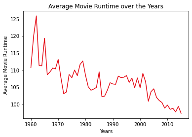

```python
# plotting the results
plt.plot(avg_rt.index, avg_rt, '#E50914')
plt.title('Average Movie Runtime over the Years')
plt.xlabel('Years')
plt.ylabel('Average Movie Runtime')
```

There has been a general decrease in runtime over the years

### Popular Genres from year to year

The genre column is delimited with the pipe (|) symbol so it has to be split

```python
# checking for unique genre values
movie_df['genres'].unique()
```

```
array(['Action|Adventure|Science Fiction|Thriller',
       'Adventure|Science Fiction|Thriller',
       'Action|Adventure|Science Fiction|Fantasy', ...,
       'Adventure|Drama|Action|Family|Foreign',
       'Comedy|Family|Mystery|Romance',
       'Mystery|Science Fiction|Thriller|Drama'], dtype=object)
```

```python
# assuming the maximum number of genres is 5, we'll split the genres column into 5 columns
movie_df[['first_g', 'second_g', 'third_g', 'fourth_g', 'fifth_g']] = movie_df['genres'].str.split('|', expand=True)
```

```python
# checking if the dataframe changed
movie_df.head(3)
```

|  | id | popularity | original_title | cast | director | runtime | genres | production_companies | vote_average | release_year | budget_adj | revenue_adj | first_g | second_g | third_g | fourth_g | fifth_g |
| --- | --- | --- | --- | --- | --- | --- | --- | --- | --- | --- | --- | --- | --- | --- | --- | --- | --- |
| 0 | 135397 | 32.985763 | Jurassic World | Chris Pratt\|Bryce Dallas Howard\|Irrfan Khan\|Vi... | Colin Trevorrow | 124 | Action\|Adventure\|Science Fiction\|Thriller | Universal Studios\|Amblin Entertainment\|Legenda... | 6.5 | 2015 | 1.379999e+08 | 1.392446e+09 | Action | Adventure | Science Fiction | Thriller | None |
| 1 | 76341 | 28.419936 | Mad Max: Fury Road | Tom Hardy\|Charlize Theron\|Hugh Keays-Byrne\|Nic... | George Miller | 120 | Action\|Adventure\|Science Fiction\|Thriller | Village Roadshow Pictures\|Kennedy Miller Produ... | 7.1 | 2015 | 1.379999e+08 | 3.481613e+08 | Action | Adventure | Science Fiction | Thriller | None |
| 2 | 262500 | 13.112507 | Insurgent | Shailene Woodley\|Theo James\|Kate Winslet\|Ansel... | Robert Schwentke | 119 | Adventure\|Science Fiction\|Thriller | Summit Entertainment\|Mandeville Films\|Red Wago... | 6.3 | 2015 | 1.012000e+08 | 2.716190e+08 | Adventure | Science Fiction | Thriller | None | None |

```python
# dropping the genres column
movie_df.drop('genres', axis=1, inplace=True)
```

```python
# copying the dataframe
mv_df2 = movie_df.copy()
```

```python
# changing the data from wide to long format
mv_df2 = mv_df2.melt(id_vars='release_year', value_vars=['first_g', 'second_g', 'third_g', 'fourth_g', 'fifth_g'], value_name='genres')
```

```python
# grouping the genres by their release year and assigning the results to a new Dataframe
mv_ry = pd.DataFrame(mv_df2.groupby(['release_year'])['genres'].value_counts())
```

```python
# checking through the first 20 rows of the dataframe
mv_ry.head(20)
```

| release_year | genres | genres |
| --- | --- | --- |
| 1960 | Drama | 13 |
|  | Action | 8 |
|  | Comedy | 8 |
|  | Horror | 7 |
|  | Romance | 6 |
|  | Thriller | 6 |
|  | Western | 6 |
|  | Adventure | 5 |
|  | History | 5 |
|  | Family | 3 |
|  | Science Fiction | 3 |
|  | Crime | 2 |
|  | Fantasy | 2 |
|  | War | 2 |
|  | Foreign | 1 |
|  | Music | 1 |
| 1961 | Drama | 16 |
|  | Comedy | 10 |
|  | Action | 7 |
|  | Romance | 7 |

I could not figure a way to rearrange the mv_ry dataframe into 3 separate columns so I will convert to a csv file, reformat and import again

```python
# converting to csv file
mv_ry.to_csv('genres.csv', index=True)
```

```python
# importing the formatted file
mv_ry = pd.read_csv('/content/genres-conv.csv')
```

```python
# viewing the first 5 rows
mv_ry.head()
```

|  | release_year | genres | value_count |
| --- | --- | --- | --- |
| 0 | 1960 | Drama | 13 |
| 1 | 1961 | Drama | 16 |
| 2 | 1962 | Drama | 19 |
| 3 | 1963 | Comedy | 13 |
| 4 | 1963 | Drama | 13 |

```python
# getting the popular genres in each year
max_genres = mv_ry.groupby('release_year')['value_count'].transform(max)==mv_ry['value_count']
popular_genres = mv_ry[max_genres]
popular_genres
```

|  | release_year | genres | value_count |
| --- | --- | --- | --- |
| 0 | 1960 | Drama | 13 |
| 1 | 1961 | Drama | 16 |
| 2 | 1962 | Drama | 19 |
| 3 | 1963 | Comedy | 13 |
| 4 | 1963 | Drama | 13 |
| 5 | 1964 | Drama | 20 |
| 6 | 1965 | Drama | 19 |
| 7 | 1966 | Comedy | 15 |
| 8 | 1966 | Drama | 15 |
| 9 | 1967 | Comedy | 16 |
| 10 | 1967 | Drama | 16 |
| 11 | 1968 | Drama | 19 |
| 12 | 1969 | Drama | 13 |
| 13 | 1970 | Drama | 19 |
| 14 | 1971 | Drama | 30 |
| 15 | 1972 | Drama | 16 |
| 16 | 1973 | Drama | 31 |
| 17 | 1974 | Drama | 21 |
| 18 | 1975 | Drama | 17 |
| 19 | 1976 | Drama | 22 |
| 20 | 1977 | Drama | 23 |
| 21 | 1978 | Drama | 28 |
| 22 | 1979 | Drama | 30 |
| 23 | 1980 | Drama | 32 |
| 24 | 1981 | Drama | 32 |
| 25 | 1982 | Drama | 33 |
| 26 | 1983 | Drama | 34 |
| 27 | 1984 | Comedy | 37 |
| 28 | 1984 | Drama | 37 |
| 29 | 1985 | Comedy | 50 |
| 30 | 1986 | Drama | 48 |
| 31 | 1987 | Comedy | 53 |
| 32 | 1988 | Comedy | 65 |
| 33 | 1989 | Comedy | 59 |
| 34 | 1990 | Drama | 58 |
| 35 | 1991 | Drama | 62 |
| 36 | 1992 | Drama | 63 |
| 37 | 1993 | Drama | 89 |
| 38 | 1994 | Comedy | 83 |
| 39 | 1995 | Drama | 92 |
| 40 | 1996 | Drama | 100 |
| 41 | 1997 | Drama | 78 |
| 42 | 1998 | Drama | 97 |
| 43 | 1999 | Drama | 109 |
| 44 | 2000 | Drama | 88 |
| 45 | 2001 | Comedy | 89 |
| 46 | 2002 | Drama | 117 |
| 47 | 2003 | Comedy | 102 |
| 48 | 2004 | Drama | 116 |
| 49 | 2005 | Drama | 158 |
| 50 | 2006 | Drama | 177 |
| 51 | 2007 | Drama | 180 |
| 52 | 2008 | Drama | 211 |
| 53 | 2009 | Drama | 199 |
| 54 | 2010 | Drama | 189 |
| 55 | 2011 | Drama | 185 |
| 56 | 2012 | Drama | 202 |
| 57 | 2013 | Drama | 228 |
| 58 | 2014 | Drama | 270 |
| 59 | 2015 | Drama | 233 |

```python
# getting the unique genres
unique_genres = np.unique(popular_genres['genres']).tolist()
unique_genres
```

```
['Comedy', 'Drama']
```

Comedy and Drama have been the most popular genres since 1960!

Because there are many values, it's best practice to leave the visualization as a table (or dataframe, in this case).

### Popular Production Companies from year to year

The production companies column is delimited with the pipe (|) symbol so it has to be split

```python
# checking for unique genre values
movie_df['production_companies'].unique()
```

```
array(['Universal Studios|Amblin Entertainment|Legendary Pictures|Fuji Television Network|Dentsu',
       'Village Roadshow Pictures|Kennedy Miller Productions',
       'Summit Entertainment|Mandeville Films|Red Wagon Entertainment|NeoReel',
       ...,
       'Cherokee Productions|Joel Productions|Douglas & Lewis Productions',
       'Benedict Pictures Corp.', 'Norm-Iris'], dtype=object)
```

```python
# assuming the maximum number of production companies for a movie is 5, we'll split the production_companies column into 5 columns
movie_df[['first_pc', 'second_pc', 'third_pc', 'fourth_pc', 'fifth_pc']] = movie_df['production_companies'].str.split('|', expand=True)
```

```python
# checking if the dataframe changed
movie_df.head()
```

|  | id | popularity | original_title | cast | director | runtime | production_companies | vote_average | release_year | budget_adj | ... | first_g | second_g | third_g | fourth_g | fifth_g | first_pc | second_pc | third_pc | fourth_pc | fifth_pc |
| --- | --- | --- | --- | --- | --- | --- | --- | --- | --- | --- | --- | --- | --- | --- | --- | --- | --- | --- | --- | --- | --- |
| 0 | 135397 | 32.985763 | Jurassic World | Chris Pratt\|Bryce Dallas Howard\|Irrfan Khan\|Vi... | Colin Trevorrow | 124 | Universal Studios\|Amblin Entertainment\|Legenda... | 6.5 | 2015 | 1.379999e+08 | ... | Action | Adventure | Science Fiction | Thriller | None | Universal Studios | Amblin Entertainment | Legendary Pictures | Fuji Television Network | Dentsu |
| 1 | 76341 | 28.419936 | Mad Max: Fury Road | Tom Hardy\|Charlize Theron\|Hugh Keays-Byrne\|Nic... | George Miller | 120 | Village Roadshow Pictures\|Kennedy Miller Produ... | 7.1 | 2015 | 1.379999e+08 | ... | Action | Adventure | Science Fiction | Thriller | None | Village Roadshow Pictures | Kennedy Miller Productions | None | None | None |
| 2 | 262500 | 13.112507 | Insurgent | Shailene Woodley\|Theo James\|Kate Winslet\|Ansel... | Robert Schwentke | 119 | Summit Entertainment\|Mandeville Films\|Red Wago... | 6.3 | 2015 | 1.012000e+08 | ... | Adventure | Science Fiction | Thriller | None | None | Summit Entertainment | Mandeville Films | Red Wagon Entertainment | NeoReel | None |
| 3 | 140607 | 11.173104 | Star Wars: The Force Awakens | Harrison Ford\|Mark Hamill\|Carrie Fisher\|Adam D... | J.J. Abrams | 136 | Lucasfilm\|Truenorth Productions\|Bad Robot | 7.5 | 2015 | 1.839999e+08 | ... | Action | Adventure | Science Fiction | Fantasy | None | Lucasfilm | Truenorth Productions | Bad Robot | None | None |
| 4 | 168259 | 9.335014 | Furious 7 | Vin Diesel\|Paul Walker\|Jason Statham\|Michelle ... | James Wan | 137 | Universal Pictures\|Original Film\|Media Rights ... | 7.3 | 2015 | 1.747999e+08 | ... | Action | Crime | Thriller | None | None | Universal Pictures | Original Film | Media Rights Capital | Dentsu | One Race Films |

5 rows × 21 columns

```python
# dropping the production companies column
movie_df.drop('production_companies', axis=1, inplace=True)
```

```python
# copying the dataframe
pc_df2 = movie_df.copy()
```

```python
# changing the data from wide to long format
pc_df2 = pc_df2.melt(id_vars='release_year', value_vars=['first_pc', 'second_pc', 'third_pc', 'fourth_pc', 'fifth_pc'], value_name='production_companies')
```

```python
# grouping the production companies by their release year and assigning the results to a new Dataframe
pc_ry = pd.DataFrame(pc_df2.groupby(['release_year'])['production_companies'].value_counts())
```

```python
# checking through the first 10 rows of the dataframe
pc_ry.head(10)
```

| release_year | production_companies | production_companies |
| --- | --- | --- |
| 1960 | Twentieth Century Fox Film Corporation | 4 |
|  | United Artists | 3 |
|  | Jerry Lewis Productions | 2 |
|  | Paramount Pictures | 2 |
|  | Alpha Productions | 1 |
|  | Alta Vista Productions | 1 |
|  | Anglo-Amalgamated Productions | 1 |
|  | Arwin Productions | 1 |
|  | Batjac Productions | 1 |
|  | Bryna Productions | 1 |

I could not figure a way to rearrange the pc_ry dataframe into 3 separate columns so I will convert to a csv file, reformat and import again

```python
# converting to csv file
pc_ry.to_csv('companies.csv', index=True)
```

```python
# importing the formatted file
pc_ry = pd.read_csv('/content/companies-conv.csv')
```

```python
# viewing the first 5 rows
pc_ry.head()
```

|  | release_year | production_companies | value_counts |
| --- | --- | --- | --- |
| 0 | 1960 | Twentieth Century Fox Film Corporation | 4 |
| 1 | 1961 | Columbia Pictures Corporation | 3 |
| 2 | 1961 | Twentieth Century Fox Film Corporation | 3 |
| 3 | 1961 | United Artists | 3 |
| 4 | 1962 | Metro-Goldwyn-Mayer (MGM) | 4 |

```python
# getting the popular production companies in each year
pop_prod_comp = pc_ry.groupby('release_year')['value_counts'].transform(max)==pc_ry['value_counts']
popular_comp = pc_ry[pop_prod_comp]
popular_comp
```

|  | release_year | production_companies | value_counts |
| --- | --- | --- | --- |
| 0 | 1960 | Twentieth Century Fox Film Corporation | 4 |
| 1 | 1961 | Columbia Pictures Corporation | 3 |
| 2 | 1961 | Twentieth Century Fox Film Corporation | 3 |
| 3 | 1961 | United Artists | 3 |
| 4 | 1962 | Metro-Goldwyn-Mayer (MGM) | 4 |
| ... | ... | ... | ... |
| 68 | 2011 | Universal Pictures | 17 |
| 69 | 2012 | Relativity Media | 15 |
| 70 | 2013 | Universal Pictures | 13 |
| 71 | 2014 | Warner Bros. | 13 |
| 72 | 2015 | Universal Pictures | 14 |

73 rows × 3 columns

Some years have ties between more than one production company as seen above

```python
# getting the unique production companies
unique_genres = np.unique(popular_comp['production_companies']).tolist()
unique_genres
```

```
['Allied Artists Pictures',
 'Alta Vista Productions',
 'Columbia Pictures Corporation',
 'Metro-Goldwyn-Mayer (MGM)',
 'Miramax Films',
 'Paramount Pictures',
 'Relativity Media',
 'TriStar Pictures',
 'Twentieth Century Fox Film Corporation',
 'United Artists',
 'Universal Pictures',
 'Walt Disney Pictures',
 'Warner Bros.']
```

```python
# number of popular production companies
len(unique_genres)
```

```
13
```

There has been 13 popular production companies since 1960!

Because there are many values, it's best practice to leave the visualization as a table (or dataframe, in this case).

### Factors that possibly influence movies with high revenues

```python
# function to simplify plotting the scatter plots
def plot_relationship(column_name):
  plt.scatter(x=movie_df['revenue_adj'], y=movie_df[column_name])
  plt.title('Relationship between {} and revenue'.format(column_name))
  plt.xlabel('Revenues')
  plt.ylabel(column_name)
```

```python
# list of variables to compare revenues with
comparison_list = ['popularity', 'runtime', 'vote_average', 'budget_adj']
```

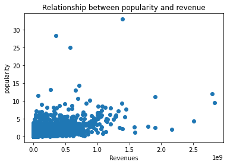

```python
# plotting our relationships - Popularity and Revenue
plot_relationship(comparison_list[0])
```

There is a weak positive correlation between popularity of the movie and the revenue generated.

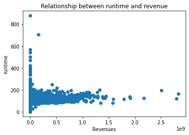

```python
# plotting our relationships - Runtime and Revenue
plot_relationship(comparison_list[1])
```

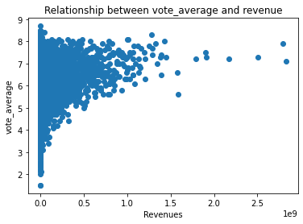

```python
# plotting our relationships - Average votes and Revenue
plot_relationship(comparison_list[2])
```

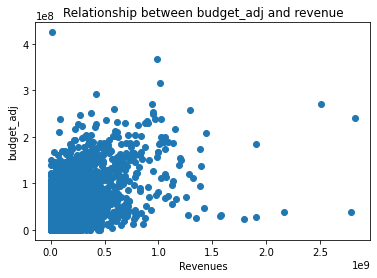

```python
# plotting our relationships - Budget and Revenue
plot_relationship(comparison_list[3])
```

There is a weak positive correlation between the budget and the revenue generated.

## Conclusions

### Limitations

> - I assumed the maximum number of genres and production companies for each movie to be 5.